# Summary HEQU

Sanne Evers

September 18, 2019

$~$

I will be using this document to summarise the progress on the HEQU Climwin analysis.

The general README file with origin of the datasets and layout can be found [here](https://github.com/SanneE1/Biome), although the repository is currently still set on private. Most/All of the analyses and visuals can also be found there.

$~$

# Climate data

### Locations

Below you’ll find a table with site information for the populations as well as a map with the location of the populations and the closest NOAA weather stations.

For the weather station we selected the NOAA station "USS0006L11S" (green in the following map and figures). If we were to select the closest station per population, the closest stations for the high and mid populations (red and green resp.) would have been almost 20 km apart, while the actual populations are relatively close together. Moreover, station "USS0006L11S" is the second closest station for the high population (10km compared to 7.8 km). This station is also only 2.5 km further away from the low population compared to the closest station "USC00051959" (blue - which is missing one month of data). However, this station is in a “wildlife-urbanisation interface” (i.e. there are several buildings there - bit of a village)

| Population | Name | Latitude | Longitude | Altitude..m.a.s.l.. |
| --- | --- | --- | --- | --- |
| high | Virginia Basin | 38.97687 | -106.9782 | 3407 |
| mid | Maxfield Meadow | 38.95833 | -106.9883 | 2886 |
| low | Horse Ranch Park | 38.86290 | -107.1593 | 2703 |

[interactive chart not shown]

$~$

### Climate plots

A quick overview of the climate in the different populations

#### Temperature

The figure below shows the mean temperature at observation (black line), the average minimum and maximum temperature (blue ribbon) and the absolute minimum and maximum temperature (red dashed line) per month for each year. The values between 15-07-2002 and 15-07-2003 were imputed using the closest station, due to extreme values observed in the original data (see here)

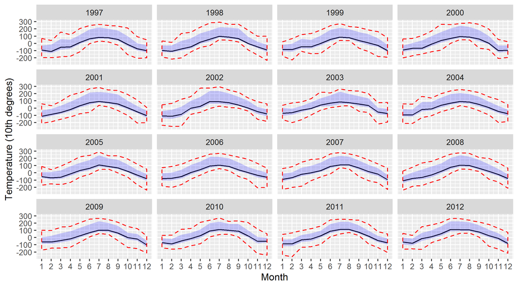

#### Precipitation

The solid line shows the daily mean precipitation per month. The ribbon is +/- standard deviation

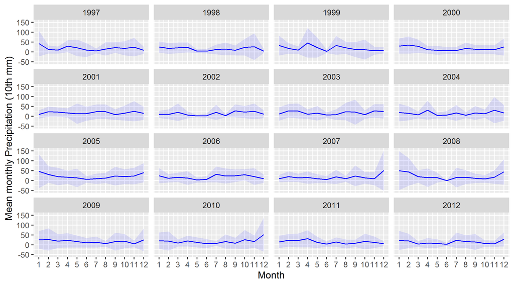

# Climwin Input Variables[^1]

$~$

## Monthly climate variables used

The tables below list all the different climate variables that are tested when using monthly data.

Climate drivers

| Abbreviation | Description |
| --- | --- |
| mean_prcp_scaled | Scaled mean percipitation (mm) in that month |
| mean_tavg_scaled | Monthly scaled mean of the average daily temperature |
| mean_tmax_scaled | Monthly scaled mean of the maximum temperature observed per day |
| mean_tmin_scaled | Monthly scaled mean of the minimum temperature observed per day |
| mean_tobs_scaled | Monthly scaled mean of the temperature at time of observation |

Aggregate statistics

| Abbreviation | Description |
| --- | --- |
| mean | The mean of the values of the climate driver within the time window |

Response type

| Abbreviation | Description |
| --- | --- |
| lin | Linear |
| quad | Quadratic |

$~$

## Daily climate variables used

The tables below list all the different climate variables that are tested when using daily climate data

*Still needs to be done*

$~$

# Climwin Analysis

## Survival

### Plot

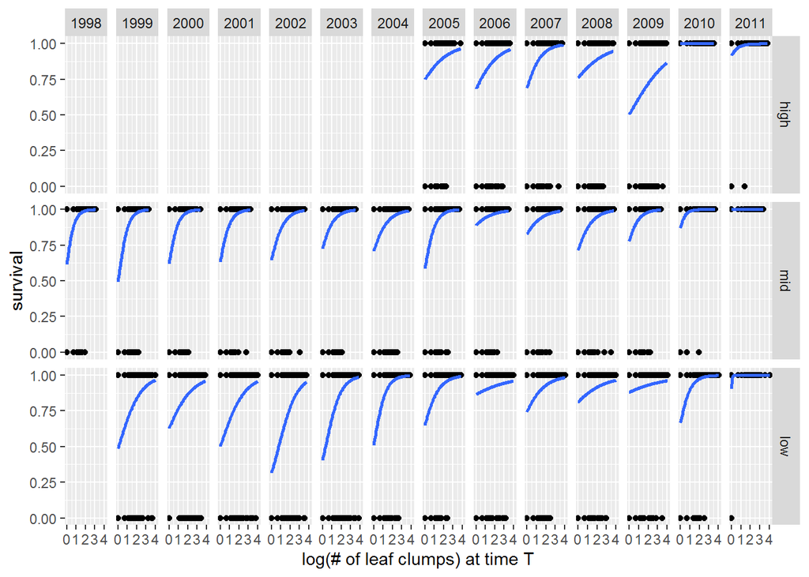

### Climwin: Baseline

The baseline model which doesn’t contain climate will be used to compare the relative improvement the different climate models offer to explain the data (more on that here).

For survival probability I used a logit generalised linear mixed effect model with (log transformed) size and populations as fixed effect, and year as random effect.

```
## Generalized linear mixed model fit by maximum likelihood (Laplace
##   Approximation) [glmerMod]
##  Family: binomial  ( logit )
## Formula: survival ~ log(sizeT) + population + (1 | year)
##    Data: df
##
##      AIC      BIC   logLik deviance df.resid
##  13947.1  13985.7  -6968.5  13937.1    16670
##
## Scaled residuals:
##     Min      1Q  Median      3Q     Max
## -9.4432  0.1283  0.2775  0.4780  1.2695
##
## Random effects:
##  Groups Name        Variance Std.Dev.
##  year   (Intercept) 0.6896   0.8304
## Number of obs: 16675, groups:  year, 14
##
## Fixed effects:
##               Estimate Std. Error z value Pr(>|z|)
## (Intercept)    0.20738    0.24026   0.863 0.388056
## log(sizeT)     0.54531    0.01565  34.838  < 2e-16 ***
## populationlow  0.36237    0.09643   3.758 0.000171 ***
## populationmid  0.94164    0.09762   9.646  < 2e-16 ***
## ---
## Signif. codes:  0 '***' 0.001 '**' 0.01 '*' 0.05 '.' 0.1 ' ' 1
##
## Correlation of Fixed Effects:
##             (Intr) lg(sT) ppltnl
## log(sizeT)  -0.119
## populatinlw -0.342  0.131
## populatinmd -0.336  0.087  0.881
```

$~$

### Climwin: Slidingwindow Summary

The table below shows the best time window for the 10 tried combinations. It is sorted on the best fit first (i.e. the lowest DeltaAICc first, see here).

**The reference month for the time windows is July** (i.e. month 0 )  
Note on the time windows

| Combination | Response | Climate Variable | Type | Aggregate statistic | Function | DeltaAICc | WindowOpen | WindowClose |
| --- | --- | --- | --- | --- | --- | --- | --- | --- |
| 8 | survival | mean_tobs_scaled | absolute | mean | quad | -32.54 | 11 | -8 |
| 10 | survival | mean_tmin_scaled | absolute | mean | quad | -23.23 | 12 | -11 |
| 9 | survival | mean_tmax_scaled | absolute | mean | quad | -16.99 | 5 | 2 |
| 7 | survival | mean_prcp_scaled | absolute | mean | quad | -16.22 | 1 | -9 |
| 5 | survival | mean_tmin_scaled | absolute | mean | lin | -15.33 | 1 | -3 |
| 3 | survival | mean_tobs_scaled | absolute | mean | lin | -15.01 | 1 | -1 |
| 2 | survival | mean_tavg_scaled | absolute | mean | quad | -7.67 | 7 | -10 |
| 1 | survival | mean_prcp_scaled | absolute | mean | lin | -6.38 | 4 | -11 |
| 4 | survival | mean_tmax_scaled | absolute | mean | lin | -3.01 | 2 | 2 |
| 6 | survival | mean_tavg_scaled | absolute | mean | lin | -1.37 | 7 | 7 |

$~$

### Climwin: Best Window

Selected combination

| Response | Climate Variable | Type | Aggregate statistic | Function | DeltaAICc | WindowOpen | WindowClose |
| --- | --- | --- | --- | --- | --- | --- | --- |
| survival | mean_tobs_scaled | absolute | mean | quad | -32.54 | 11 | -8 |

Top 10 windows of selected combination (above)

| deltaAICc | WindowOpen | WindowClose | ModelBeta | ModelInt | Function | Statistics |
| --- | --- | --- | --- | --- | --- | --- |
| -32.54403 | 11 | -8 | 1.845434 | -0.5166494 | quad | mean |
| -32.21564 | 10 | -8 | 1.876938 | -0.5411155 | quad | mean |
| -31.65683 | 10 | -7 | 1.991254 | -0.5939156 | quad | mean |
| -31.47692 | 11 | -9 | 1.770501 | -0.4853468 | quad | mean |
| -31.34126 | 11 | -7 | 1.947671 | -0.5563800 | quad | mean |
| -30.91763 | 10 | -6 | 1.971600 | -0.5436323 | quad | mean |
| -30.11726 | 11 | -6 | 1.917261 | -0.4921025 | quad | mean |
| -29.86110 | 10 | -9 | 1.774839 | -0.5042069 | quad | mean |
| -29.70268 | 11 | -10 | 1.746935 | -0.4296689 | quad | mean |
| -29.62356 | 4 | -12 | 1.349670 | -0.4546349 | quad | mean |

```
## Generalized linear mixed model fit by maximum likelihood (Laplace
##   Approximation) [glmerMod]
##  Family: binomial  ( logit )
## Formula: yvar ~ lnsizeT + population + (1 | year) + climate + I(climate^2)
##    Data: modeldat
##
##      AIC      BIC   logLik deviance df.resid
##  13579.3  13633.4  -6782.7  13565.3    16668
##
## Scaled residuals:
##      Min       1Q   Median       3Q      Max
## -12.7222   0.1012   0.2546   0.4809   1.3150
##
## Random effects:
##  Groups Name        Variance Std.Dev.
##  year   (Intercept) 0.04252  0.2062
## Number of obs: 16675, groups:  year, 14
##
## Fixed effects:
##               Estimate Std. Error z value Pr(>|z|)
## (Intercept)   -0.51665    0.13470  -3.835 0.000125 ***
## lnsizeT        1.07134    0.02990  35.834  < 2e-16 ***
## populationlow  0.37926    0.09764   3.884 0.000103 ***
## populationmid  1.15709    0.09884  11.707  < 2e-16 ***
## climate        1.84543    0.16999  10.856  < 2e-16 ***
## I(climate^2)   2.70447    0.40437   6.688 2.26e-11 ***
## ---
## Signif. codes:  0 '***' 0.001 '**' 0.01 '*' 0.05 '.' 0.1 ' ' 1
##
## Correlation of Fixed Effects:
##             (Intr) lnsizT ppltnl ppltnm climat
## lnsizeT     -0.244
## populatinlw -0.632  0.143
## populatinmd -0.624  0.121  0.883
## climate     -0.372 -0.045  0.118  0.139
## I(climat^2) -0.607  0.034  0.024  0.022  0.597
```

$~$

### Climwin: Plotall

The following graph shows the output from the `plot_all` function from `Climwin`.

Upper left shows the different opening (y-axis) and closing (x-axis) times and the corresponding `dAICc`. The red area’s show the timewindows with the lowest `dAICc` (Remember, lower is better)

Lower left shows the comparison between the chosen best window, and the `dAICc` of the 500 random models

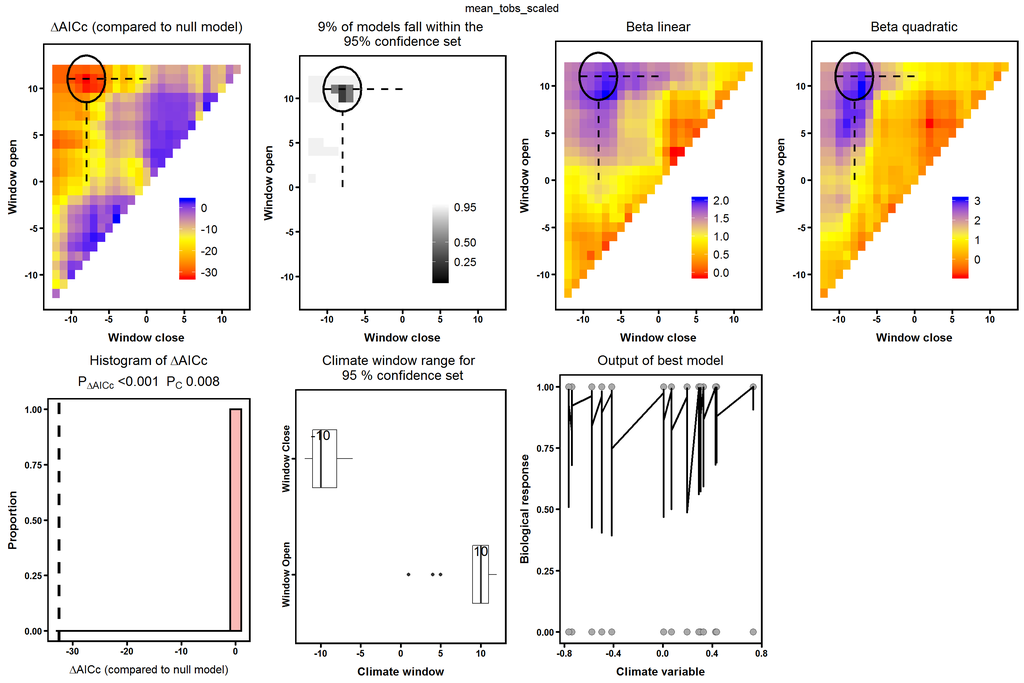

$~$

## Growth

### Plot

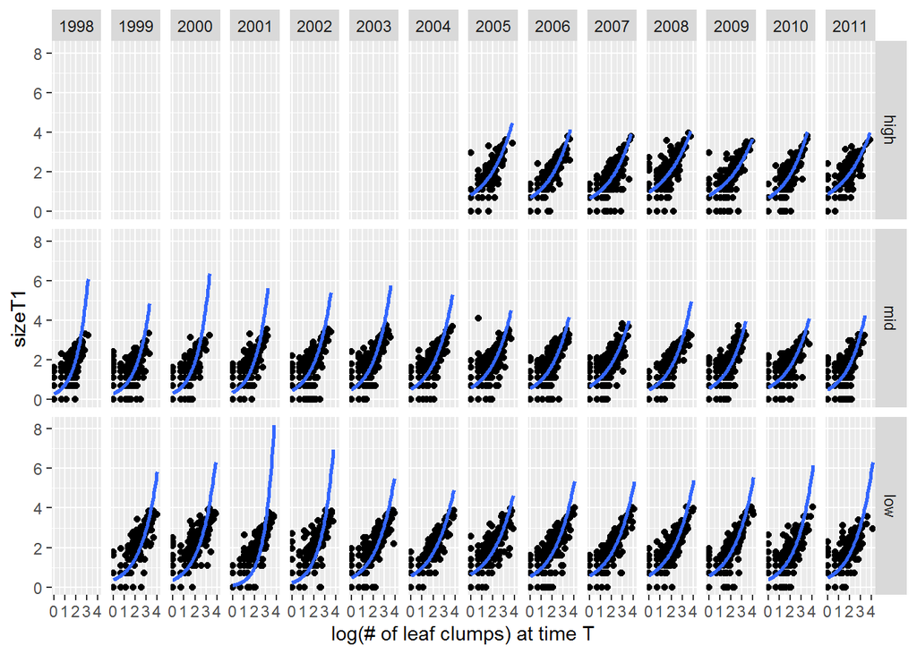

### Climwin: Baseline

The plan is to use a negative binomial model: `glmer.nb(sizeT1 ~ sizeT + population + (1|year), data = Biol)` However, as it’ll probably take a long time and with EVE shutting down on Friday, the results below are from a Poisson distribution

**Current baseline**

```
## Generalized linear mixed model fit by maximum likelihood (Laplace
##   Approximation) [glmerMod]
##  Family: poisson  ( log )
## Formula: sizeT1 ~ sizeT + population + (1 | year)
##    Data: df
##
##       AIC       BIC    logLik  deviance  df.resid
##  226626.2  226663.3 -113308.1  226616.2     12123
##
## Scaled residuals:
##     Min      1Q  Median      3Q     Max
## -7.0287 -2.9061 -0.7284  1.9654 16.1224
##
## Random effects:
##  Groups Name        Variance Std.Dev.
##  year   (Intercept) 0.01193  0.1092
## Number of obs: 12128, groups:  year, 14
##
## Fixed effects:
##                 Estimate Std. Error z value Pr(>|z|)
## (Intercept)    2.531e+00  2.990e-02  84.637   <2e-16 ***
## sizeT          2.189e-02  8.954e-05 244.511   <2e-16 ***
## populationlow -1.218e-01  6.526e-03 -18.658   <2e-16 ***
## populationmid  8.569e-03  6.082e-03   1.409    0.159
## ---
## Signif. codes:  0 '***' 0.001 '**' 0.01 '*' 0.05 '.' 0.1 ' ' 1
##
## Correlation of Fixed Effects:
##             (Intr) sizeT  ppltnl
## sizeT       -0.108
## populatinlw -0.162  0.073
## populatinmd -0.172  0.023  0.758
## convergence code: 0
## Model failed to converge with max|grad| = 0.00268418 (tol = 0.001, component 1)
## Model is nearly unidentifiable: very large eigenvalue
##  - Rescale variables?
```

### Climwin: Slidingwindow Summary

$~$

**The reference month for the time windows is July** (i.e. month 0 ) Note on the time windows

| Combination | Response | Climate Variable | Type | Aggregate statistic | Function | DeltaAICc | WindowOpen | WindowClose |
| --- | --- | --- | --- | --- | --- | --- | --- | --- |
| 8 | sizeT1 | mean_tobs_scaled | absolute | mean | quad | -20.49 | 8 | -8 |
| 10 | sizeT1 | mean_tmin_scaled | absolute | mean | quad | -16.39 | 11 | -8 |
| 9 | sizeT1 | mean_tmax_scaled | absolute | mean | quad | -10.78 | -10 | -12 |
| 7 | sizeT1 | mean_prcp_scaled | absolute | mean | quad | -10.18 | -2 | -2 |
| 4 | sizeT1 | mean_tmax_scaled | absolute | mean | lin | -7.70 | 9 | -8 |
| 1 | sizeT1 | mean_prcp_scaled | absolute | mean | lin | -5.77 | -2 | -2 |
| 2 | sizeT1 | mean_tavg_scaled | absolute | mean | quad | -5.37 | 9 | 8 |
| 5 | sizeT1 | mean_tmin_scaled | absolute | mean | lin | -5.23 | -7 | -7 |
| 3 | sizeT1 | mean_tobs_scaled | absolute | mean | lin | -3.12 | 9 | 8 |
| 6 | sizeT1 | mean_tavg_scaled | absolute | mean | lin | -2.30 | 5 | 2 |

$~$

### Climwin: Best Window

Selected combination

| Response | Climate Variable | Type | Aggregate statistic | Function | DeltaAICc | WindowOpen | WindowClose |
| --- | --- | --- | --- | --- | --- | --- | --- |
| sizeT1 | mean_tobs_scaled | absolute | mean | quad | -20.49 | 8 | -8 |

Top 10 windows of selected combination (above)

| deltaAICc | WindowOpen | WindowClose | ModelBeta | ModelInt | Function | Statistics |
| --- | --- | --- | --- | --- | --- | --- |
| -20.48717 | 8 | -8 | 0.0025105 | 1.698227 | quad | mean |
| -19.02201 | 11 | -8 | 0.0098103 | 1.687205 | quad | mean |
| -18.55133 | 7 | -8 | 0.0389596 | 1.698078 | quad | mean |
| -18.32364 | 10 | -8 | 0.0167216 | 1.680832 | quad | mean |
| -17.64288 | 6 | -8 | 0.0312821 | 1.699403 | quad | mean |
| -16.83185 | 9 | -8 | -0.0123917 | 1.691160 | quad | mean |
| -15.30094 | 12 | -8 | 0.0164759 | 1.682767 | quad | mean |
| -14.53086 | 8 | -7 | -0.0035370 | 1.700706 | quad | mean |
| -14.26043 | 8 | -9 | 0.0389936 | 1.679906 | quad | mean |
| -13.99685 | 1 | -10 | 0.1552247 | 1.640656 | quad | mean |

```
## Generalized linear mixed model fit by maximum likelihood (Laplace
##   Approximation) [glmerMod]
##  Family: poisson  ( log )
## Formula: yvar ~ sizeT + population + (1 | year) + climate + I(climate^2)
##    Data: modeldat
##
##      AIC      BIC   logLik deviance df.resid
##  68856.2  68908.0 -34421.1  68842.2    12120
##
## Scaled residuals:
##      Min       1Q   Median       3Q      Max
## -28.8323  -1.1985  -0.4612   0.7219  13.6574
##
## Random effects:
##  Groups Name        Variance Std.Dev.
##  year   (Intercept) 0.00306  0.05531
## Number of obs: 12127, groups:  year, 14
##
## Fixed effects:
##                 Estimate Std. Error z value Pr(>|z|)
## (Intercept)    1.6982265  0.0286176  59.342  < 2e-16 ***
## sizeT          0.0536140  0.0002416 221.934  < 2e-16 ***
## populationlow -0.1806808  0.0120617 -14.980  < 2e-16 ***
## populationmid -0.2570166  0.0119111 -21.578  < 2e-16 ***
## climate        0.0025105  0.0379430   0.066    0.947
## I(climate^2)  -0.6564791  0.0949437  -6.914  4.7e-12 ***
## ---
## Signif. codes:  0 '***' 0.001 '**' 0.01 '*' 0.05 '.' 0.1 ' ' 1
##
## Correlation of Fixed Effects:
##             (Intr) sizeT  ppltnl ppltnm climat
## sizeT       -0.063
## populatinlw -0.313 -0.172
## populatinmd -0.347  0.046  0.742
## climate     -0.438 -0.057  0.067  0.076
## I(climat^2) -0.768 -0.019  0.018  0.022  0.523
## convergence code: 0
## Model failed to converge with max|grad| = 0.00348255 (tol = 0.001, component 1)
## Model is nearly unidentifiable: very large eigenvalue
##  - Rescale variables?
```

### Climwin: Plotall

The following graph shows the output from the `plot_all` function from `Climwin`.

Upper left shows the different opening (y-axis) and closing (x-axis) times and the corresponding `dAICc`. The red area’s show the timewindows with the lowest `dAICc` (Remember, lower is better)

Lower left shows the comparison between the chosen best window, and the `dAICc` of the 500 random models

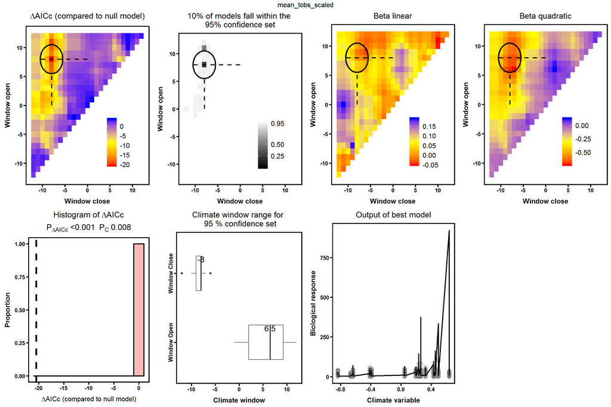

## Flower probability

### Plot

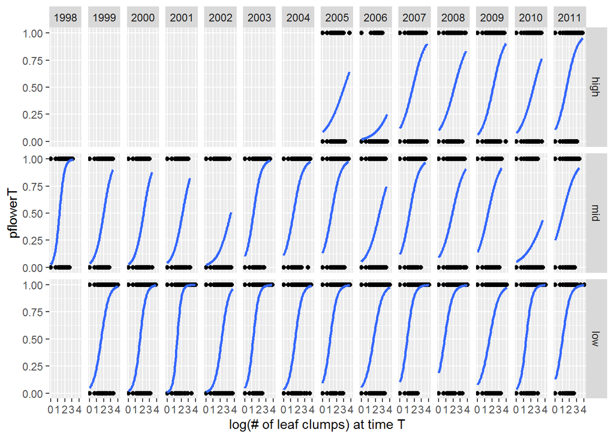

### Climwin: Baseline

**Current baseline**

```
## Generalized linear mixed model fit by maximum likelihood (Laplace
##   Approximation) [glmerMod]
##  Family: binomial  ( logit )
## Formula: pflowerT1 ~ log(sizeT1) + population + (1 | year)
##    Data: df
##
##      AIC      BIC   logLik deviance df.resid
##  14024.3  14061.8  -7007.2  14014.3    13289
##
## Scaled residuals:
##     Min      1Q  Median      3Q     Max
## -2.4742 -0.6988 -0.2681  0.7652 10.4903
##
## Random effects:
##  Groups Name        Variance Std.Dev.
##  year   (Intercept) 1.102    1.05
## Number of obs: 13294, groups:  year, 14
##
## Fixed effects:
##               Estimate Std. Error z value Pr(>|z|)
## (Intercept)   -2.37282    0.29252  -8.112    5e-16 ***
## log(sizeT1)    0.52750    0.01548  34.074   <2e-16 ***
## populationlow  1.06625    0.07501  14.214   <2e-16 ***
## populationmid  0.07983    0.07192   1.110    0.267
## ---
## Signif. codes:  0 '***' 0.001 '**' 0.01 '*' 0.05 '.' 0.1 ' ' 1
##
## Correlation of Fixed Effects:
##             (Intr) lg(T1) ppltnl
## log(sizeT1) -0.156
## populatinlw -0.223  0.168
## populatinmd -0.208  0.003  0.794
```

### Climwin: Slidingwindow Summary

*To keep the script generic I need to use the same time range `c(12,-12)` as for the other vital rates. This means that both flower probability and size used are from time T+1.*

**The reference month for the time windows is July** (i.e. month 0 ) Note on the time windows

| Combination | Response | Climate Variable | Type | Aggregate statistic | Function | DeltaAICc | WindowOpen | WindowClose |
| --- | --- | --- | --- | --- | --- | --- | --- | --- |
| 7 | pflowerT1 | mean_prcp_scaled | absolute | mean | quad | -24.63 | -8 | -11 |
| 1 | pflowerT1 | mean_prcp_scaled | absolute | mean | lin | -19.97 | -1 | -11 |
| 10 | pflowerT1 | mean_tmin_scaled | absolute | mean | quad | -17.81 | -1 | -11 |
| 8 | pflowerT1 | mean_tobs_scaled | absolute | mean | quad | -15.17 | 0 | -11 |
| 9 | pflowerT1 | mean_tmax_scaled | absolute | mean | quad | -11.42 | 11 | 11 |
| 4 | pflowerT1 | mean_tmax_scaled | absolute | mean | lin | -8.28 | -11 | -11 |
| 3 | pflowerT1 | mean_tobs_scaled | absolute | mean | lin | -5.88 | -11 | -11 |
| 2 | pflowerT1 | mean_tavg_scaled | absolute | mean | quad | -5.57 | -11 | -11 |
| 5 | pflowerT1 | mean_tmin_scaled | absolute | mean | lin | -4.98 | -11 | -11 |
| 6 | pflowerT1 | mean_tavg_scaled | absolute | mean | lin | -2.85 | -11 | -11 |

### Climwin: Best Window

*To keep the script generic I need to use the same time range `c(12,-12)` as for the other vital rates. This means that both flower probability and size used are from time T+1.*

Selected combination

| Response | Climate Variable | Type | Aggregate statistic | Function | DeltaAICc | WindowOpen | WindowClose |
| --- | --- | --- | --- | --- | --- | --- | --- |
| pflowerT1 | mean_prcp_scaled | absolute | mean | quad | -24.63 | -8 | -11 |

Top 10 windows of selected combination (above)

| deltaAICc | WindowOpen | WindowClose | ModelBeta | ModelInt | Function | Statistics |
| --- | --- | --- | --- | --- | --- | --- |
| -24.62923 | -8 | -11 | 0.8612520 | -2.836158 | quad | mean |
| -22.64095 | -1 | -10 | 2.1254032 | -3.274395 | quad | mean |
| -22.60193 | -1 | -11 | 2.1836032 | -3.365943 | quad | mean |
| -21.12145 | 0 | -11 | 2.1811040 | -3.339617 | quad | mean |
| -20.73115 | -7 | -11 | 0.4351406 | -2.609824 | quad | mean |
| -19.45471 | 1 | -11 | 3.2898317 | -3.515718 | quad | mean |
| -19.25107 | -2 | -11 | 1.9812953 | -3.279559 | quad | mean |
| -19.22694 | 0 | -10 | 2.1072200 | -3.247702 | quad | mean |
| -19.08951 | -2 | -10 | 2.0924499 | -3.158797 | quad | mean |
| -18.75879 | -2 | -9 | 2.1919909 | -3.199042 | quad | mean |

```
## Generalized linear mixed model fit by maximum likelihood (Laplace
##   Approximation) [glmerMod]
##  Family: binomial  ( logit )
## Formula:
## yvar ~ lnsizeT1 + population + (1 | year) + climate + I(climate^2)
##    Data: modeldat
##
##      AIC      BIC   logLik deviance df.resid
##  10633.3  10685.1  -5309.7  10619.3    12120
##
## Scaled residuals:
##     Min      1Q  Median      3Q     Max
## -7.0412 -0.5090 -0.1792  0.5159 11.2208
##
## Random effects:
##  Groups Name        Variance Std.Dev.
##  year   (Intercept) 0.1835   0.4284
## Number of obs: 12127, groups:  year, 14
##
## Fixed effects:
##               Estimate Std. Error z value Pr(>|z|)
## (Intercept)   -2.83616    0.18533 -15.304  < 2e-16 ***
## lnsizeT1       1.52526    0.03188  47.844  < 2e-16 ***
## populationlow  1.35744    0.08714  15.577  < 2e-16 ***
## populationmid  0.62669    0.08228   7.617 2.60e-14 ***
## climate        0.86125    0.23977   3.592 0.000328 ***
## I(climate^2)  -2.73811    0.40905  -6.694 2.17e-11 ***
## ---
## Signif. codes:  0 '***' 0.001 '**' 0.01 '*' 0.05 '.' 0.1 ' ' 1
##
## Correlation of Fixed Effects:
##             (Intr) lnszT1 ppltnl ppltnm climat
## lnsizeT1    -0.312
## populatinlw -0.394  0.190
## populatinmd -0.411  0.151  0.791
## climate     -0.186  0.039  0.003 -0.021
## I(climat^2) -0.583 -0.032 -0.017 -0.010  0.342
```

### Climwin: Plotall

*To keep the script generic I need to use the same time range `c(12,-12)` as for the other vital rates. This means that both flower probability and size used are from time T+1.*

The following graph shows the output from the `plot_all` function from `Climwin`.

Upper left shows the different opening (y-axis) and closing (x-axis) times and the corresponding `dAICc`. The red area’s show the timewindows with the lowest `dAICc` (Remember, lower is better)

Lower left shows the comparison between the chosen best window, and the `dAICc` of the 500 random models

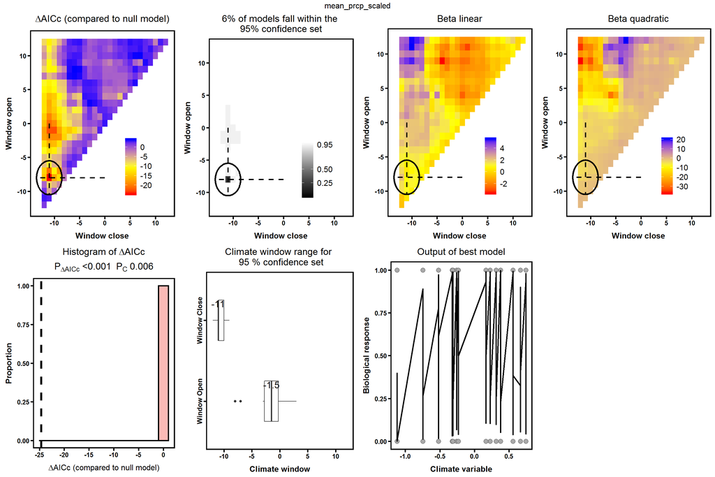

## Flower Numbers

### Plot

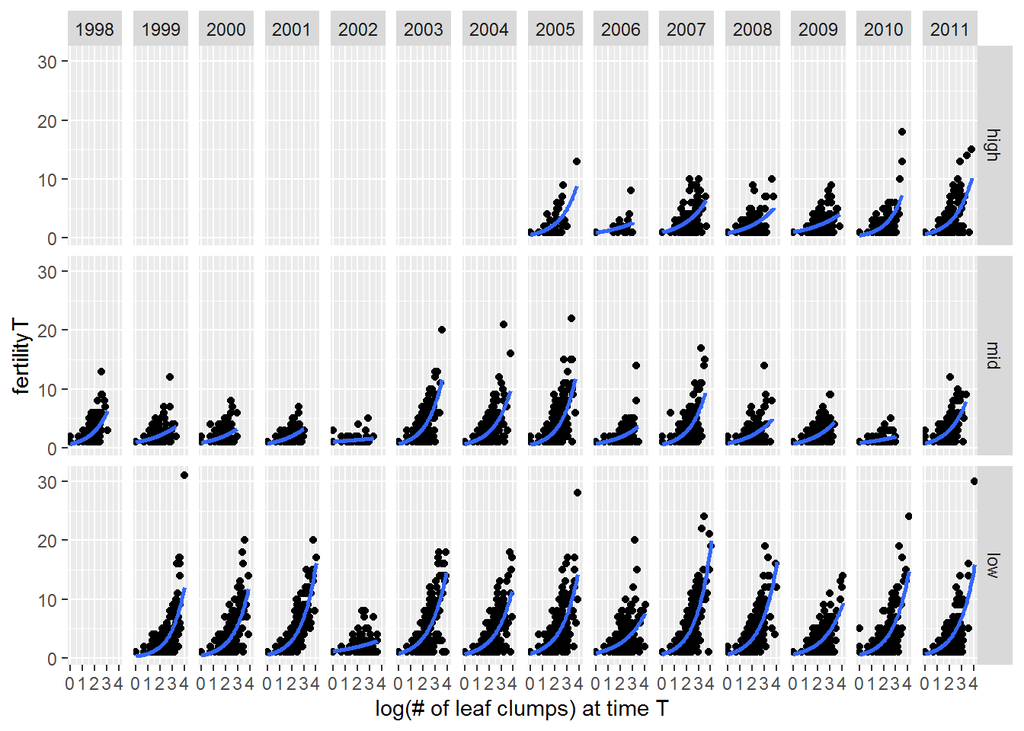

$~$

### Climwin: Baseline

The plan is to use a negative binomial model: `glmer.nb(pFlower ~ sizeT + population + (1|year), data = Biol)` However, as it’ll probably take a long time and with EVE shutting down on Friday, the results below are from a Poisson distribution

**Current baseline**

```
## Generalized linear mixed model fit by maximum likelihood (Laplace
##   Approximation) [glmerMod]
##  Family: poisson  ( log )
## Formula: fertilityT1 ~ log(sizeT1) + population + (1 | year)
##    Data: df
##
##      AIC      BIC   logLik deviance df.resid
##  22542.9  22575.5 -11266.5  22532.9     4940
##
## Scaled residuals:
##     Min      1Q  Median      3Q     Max
## -2.0020 -0.9622 -0.4248  0.5179 12.5506
##
## Random effects:
##  Groups Name        Variance Std.Dev.
##  year   (Intercept) 0.07356  0.2712
## Number of obs: 4945, groups:  year, 14
##
## Fixed effects:
##                Estimate Std. Error z value Pr(>|z|)
## (Intercept)    1.142330   0.081070  14.091  < 2e-16 ***
## log(sizeT1)   -0.066354   0.006941  -9.560  < 2e-16 ***
## populationlow  0.309402   0.030330  10.201  < 2e-16 ***
## populationmid -0.163047   0.031776  -5.131 2.88e-07 ***
## ---
## Signif. codes:  0 '***' 0.001 '**' 0.01 '*' 0.05 '.' 0.1 ' ' 1
##
## Correlation of Fixed Effects:
##             (Intr) lg(T1) ppltnl
## log(sizeT1) -0.247
## populatinlw -0.334  0.032
## populatinmd -0.315 -0.001  0.837
```

### Climwin: Slidingwindow Summary

*To keep the script generic I need to use the same time range `c(12,-12)` as for the other vital rates. This means that both the number of flowers and size used are from time T+1.*

**The reference month for the time windows is July** (i.e. month 0 ) Note on the time windows

| Combination | Response | Climate Variable | Type | Aggregate statistic | Function | DeltaAICc | WindowOpen | WindowClose |
| --- | --- | --- | --- | --- | --- | --- | --- | --- |
| 7 | fertilityT1 | mean_prcp_scaled | absolute | mean | quad | -15.37 | -7 | -11 |
| 10 | fertilityT1 | mean_tmin_scaled | absolute | mean | quad | -15.24 | -1 | -10 |
| 8 | fertilityT1 | mean_tobs_scaled | absolute | mean | quad | -13.42 | 0 | -10 |
| 9 | fertilityT1 | mean_tmax_scaled | absolute | mean | quad | -10.70 | 11 | 11 |
| 1 | fertilityT1 | mean_prcp_scaled | absolute | mean | lin | -10.23 | 1 | -11 |
| 4 | fertilityT1 | mean_tmax_scaled | absolute | mean | lin | -6.55 | -11 | -11 |
| 5 | fertilityT1 | mean_tmin_scaled | absolute | mean | lin | -4.19 | -11 | -11 |
| 3 | fertilityT1 | mean_tobs_scaled | absolute | mean | lin | -3.85 | -11 | -11 |
| 2 | fertilityT1 | mean_tavg_scaled | absolute | mean | quad | -2.89 | -2 | -2 |
| 6 | fertilityT1 | mean_tavg_scaled | absolute | mean | lin | -1.52 | -7 | -8 |

### Climwin: Best Window

*To keep the script generic I need to use the same time range `c(12,-12)` as for the other vital rates. This means that both flower probability and size used are from time T+1.*

Selected combination

| Response | Climate Variable | Type | Aggregate statistic | Function | DeltaAICc | WindowOpen | WindowClose |
| --- | --- | --- | --- | --- | --- | --- | --- |
| fertilityT1 | mean_prcp_scaled | absolute | mean | quad | -15.37 | -7 | -11 |

Top 10 windows of selected combination (above)

| deltaAICc | WindowOpen | WindowClose | ModelBeta | ModelInt | Function | Statistics |
| --- | --- | --- | --- | --- | --- | --- |
| -15.36503 | -7 | -11 | 0.0756829 | 0.7278304 | quad | mean |
| -14.50471 | -8 | -11 | 0.1736923 | 0.6829624 | quad | mean |
| -12.35048 | -2 | -12 | 0.2805815 | 0.6423968 | quad | mean |
| -11.72364 | -9 | -11 | 0.1639608 | 0.6627398 | quad | mean |
| -11.59435 | -2 | -11 | 0.3909055 | 0.5830169 | quad | mean |
| -11.34912 | -7 | -12 | 0.3122042 | 0.6668939 | quad | mean |
| -10.93649 | -1 | -11 | 0.3625009 | 0.5744081 | quad | mean |
| -10.85924 | -2 | -10 | 0.4192123 | 0.6067873 | quad | mean |
| -10.73686 | -3 | -11 | 0.3004244 | 0.6460730 | quad | mean |
| -10.26490 | -1 | -10 | 0.3936581 | 0.5879174 | quad | mean |

```
## Generalized linear mixed model fit by maximum likelihood (Laplace
##   Approximation) [glmerMod]
##  Family: poisson  ( log )
## Formula: yvar ~ sizeT1 + population + (1 | year) + climate + I(climate^2)
##    Data: modeldat
##
##      AIC      BIC   logLik deviance df.resid
##  18170.2  18215.2  -9078.1  18156.2     4594
##
## Scaled residuals:
##     Min      1Q  Median      3Q     Max
## -8.7246 -0.7973 -0.2993  0.5144  7.1867
##
## Random effects:
##  Groups Name        Variance Std.Dev.
##  year   (Intercept) 0.01601  0.1265
## Number of obs: 4601, groups:  year, 14
##
## Fixed effects:
##                 Estimate Std. Error z value Pr(>|z|)
## (Intercept)    0.7278304  0.0668621  10.886  < 2e-16 ***
## sizeT1         0.0384967  0.0005711  67.405  < 2e-16 ***
## populationlow  0.2493471  0.0312785   7.972 1.56e-15 ***
## populationmid -0.0221467  0.0324835  -0.682    0.495
## climate        0.0756829  0.0842924   0.898    0.369
## I(climate^2)  -0.8514649  0.1935640  -4.399 1.09e-05 ***
## ---
## Signif. codes:  0 '***' 0.001 '**' 0.01 '*' 0.05 '.' 0.1 ' ' 1
##
## Correlation of Fixed Effects:
##             (Intr) sizeT1 ppltnl ppltnm climat
## sizeT1      -0.110
## populatinlw -0.382 -0.108
## populatinmd -0.398  0.063  0.822
## climate     -0.394 -0.006 -0.007 -0.018
## I(climat^2) -0.723  0.006 -0.013 -0.002  0.490
## convergence code: 0
## Model is nearly unidentifiable: very large eigenvalue
##  - Rescale variables?
```

### Climwin: Plotall

*To keep the script generic I need to use the same time range `c(12,-12)` as for the other vital rates. This means that both flower probability and size used are from time T+1.*

The following graph shows the output from the `plot_all` function from `Climwin`.

Upper left shows the different opening (y-axis) and closing (x-axis) times and the corresponding `dAICc`. The red area’s show the timewindows with the lowest `dAICc` (Remember, lower is better)

Lower left shows the comparison between the chosen best window, and the `dAICc` of the 500 random models

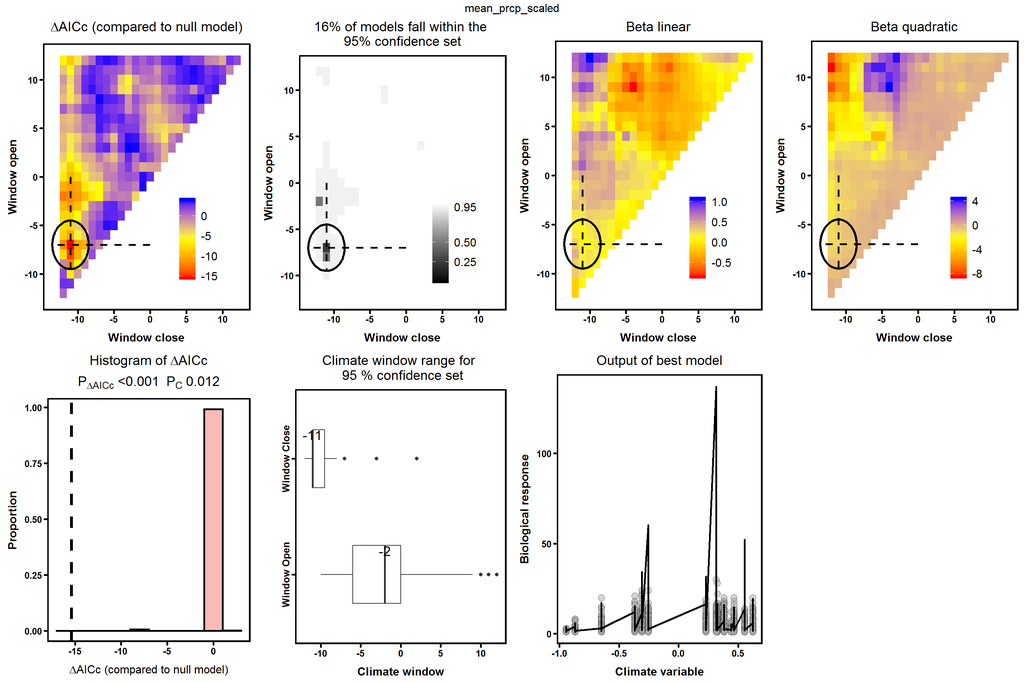

## Flower aborting probability

### Plot

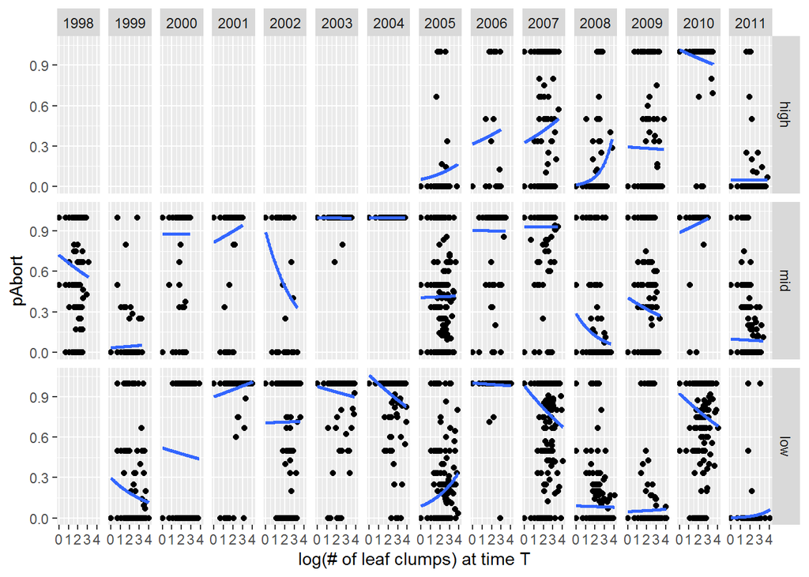

$~$

## Number of seedlings

### Plot

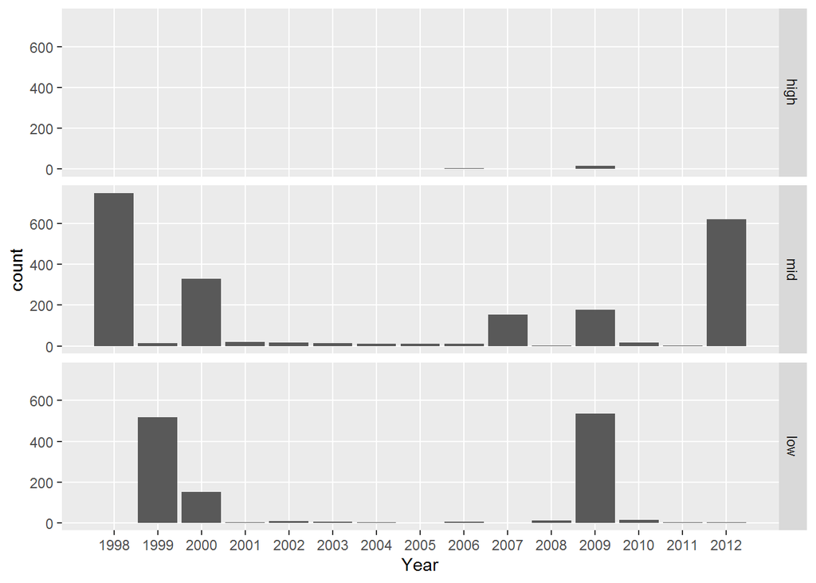

$~$  
$~$

## Seedling survival

### Plot

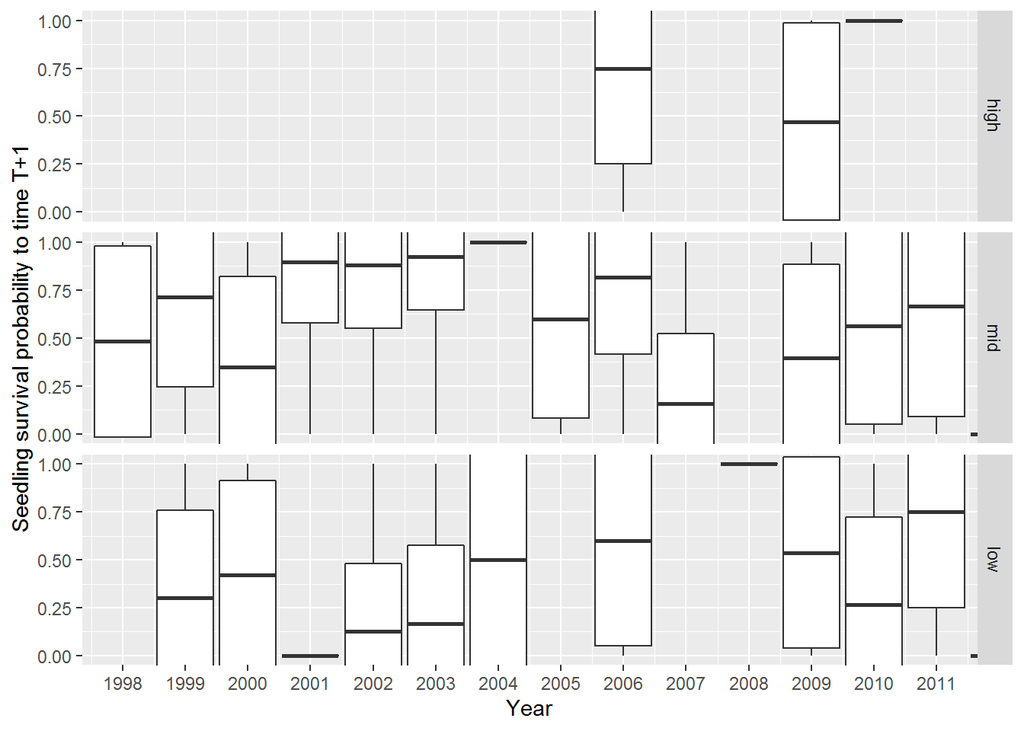

$~$

# Colinearity between Climate drivers

**Left =** Cross colinearity between `mean_tmin` and `sum_prcp`  
**Right =** Autocolinearity analysis between the `mean_tmin` critical window and all other windows

Critical window of mean_tmin was c(-1,-2)  
Critical window of sum_prcp was c(1,-6)

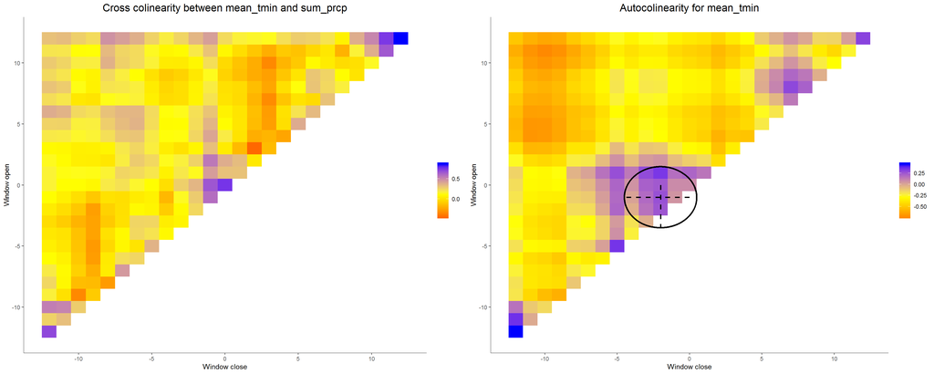

## Terms used / Extra explanation

### dAICc

The DeltaAICc is calculated as `AICc_climatemodel - AICc_baseline`. As a lower AICc score means a better fit, a negative `dAICc` means that the climate model fits better than the baseline, and the lower the `dAICc` is the better the fit is.

### Note on the time windows

The reference time for the analysis is at the time sizeT was measured. The response (e.g. survival) happens a year later. This means that when a window opens at time 0, it opens in the same month as the size was measured in. Month 12 is one year before measuring sizeT (i.e. T-1) and month -12 is the time survival is measured (i.e. T+1)

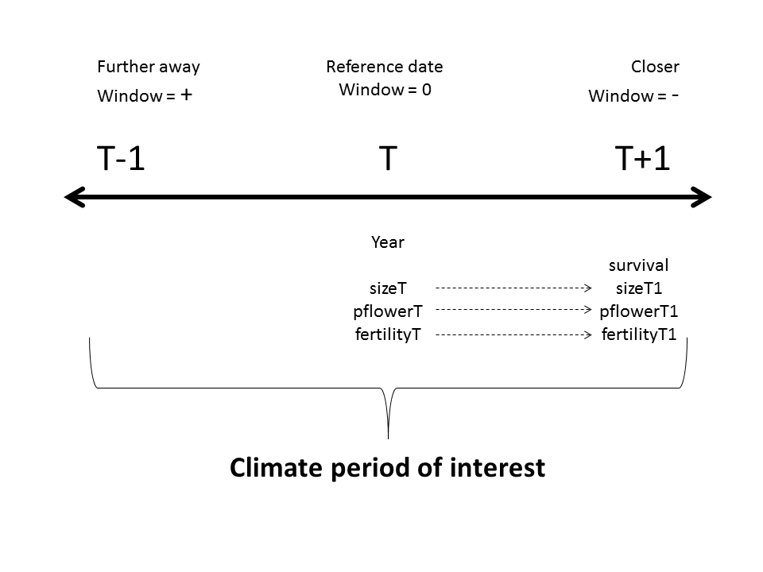

**Quick climwin test to see if using -12 works**

Range is c(12,-12)

| Combination | Response | Climate Variable | Type | Aggregate statistic | Function | DeltaAICc | WindowOpen | WindowClose |
| --- | --- | --- | --- | --- | --- | --- | --- | --- |
| 30 | survival | mean_tmax_scaled | absolute | slope | lin | -123.32 | 10 | 0 |
| 25 | survival | mean_tmax_scaled | absolute | mean | lin | -123.27 | 1 | 0 |
| 17 | survival | mean_tmax_scaled | absolute | slope | quad | -122.98 | 10 | 0 |
| 11 | survival | mean_tmax_scaled | absolute | mean | quad | -122.23 | 1 | 0 |
| 6 | survival | mean_tmax_scaled | absolute | sd | lin | -119.65 | 0 | 0 |
| 22 | survival | mean_tmax_scaled | absolute | sd | quad | -118.63 | 0 | 0 |
| 19 | survival | sum_prcp_scaled | absolute | sd | quad | -117.96 | -2 | -3 |
| 20 | survival | mean_prcp_scaled | absolute | sd | quad | -117.96 | -2 | -3 |
| 14 | survival | sum_prcp_scaled | absolute | slope | quad | -109.45 | -2 | -3 |
| 15 | survival | mean_prcp_scaled | absolute | slope | quad | -109.45 | -2 | -3 |

Range is c(24,0)

| Combination | Response | Climate Variable | Type | Aggregate statistic | Function | DeltaAICc | WindowOpen | WindowClose |
| --- | --- | --- | --- | --- | --- | --- | --- | --- |
| 30 | survival | mean_tmax_scaled | absolute | slope | lin | -123.32 | 22 | 12 |
| 25 | survival | mean_tmax_scaled | absolute | mean | lin | -123.27 | 13 | 12 |
| 17 | survival | mean_tmax_scaled | absolute | slope | quad | -122.98 | 22 | 12 |
| 11 | survival | mean_tmax_scaled | absolute | mean | quad | -122.23 | 13 | 12 |
| 6 | survival | mean_tmax_scaled | absolute | sd | lin | -119.65 | 12 | 12 |
| 22 | survival | mean_tmax_scaled | absolute | sd | quad | -118.63 | 12 | 12 |
| 19 | survival | sum_prcp_scaled | absolute | sd | quad | -117.96 | 10 | 9 |
| 20 | survival | mean_prcp_scaled | absolute | sd | quad | -117.96 | 10 | 9 |
| 14 | survival | sum_prcp_scaled | absolute | slope | quad | -109.45 | 10 | 9 |
| 15 | survival | mean_prcp_scaled | absolute | slope | quad | -109.45 | 10 | 9 |

$~$

### Random models

> The exploratory nature of climwin makes it possible that some candidate signals may occur simply by chance due to the fact that so many possible climate windows are tried. For example, when looking back 365 days, the number time windows tested is 66,795 (i.e. m(m+1)/2, with m being the maximum number of intervals, 365 here). Randomization via the function randwin is a necessary step to determine the likelihood of a climate signal occurring by chance. This function randomizes the bdate column in the original biological dataframe Biol, thereby retaining the original data structure (including other variables in the baseline model) and temperature structure, but removing any climate signal. …. Ideally one does thousands of randomizations, but a practical constraint is that this can take very long.  
> (Pol et al. 2016)

### Original Climate data from the 3 closest stations

#### Temperatures

The solid lines are the monthly mean temperature at observation ([tobs][Climwin Input Variables]) and the dashed lines are the mean minimum and maximum observed temperatures ([tmin][Climwin Input Variables] and [tmax][Climwin Input Variables] resp.)

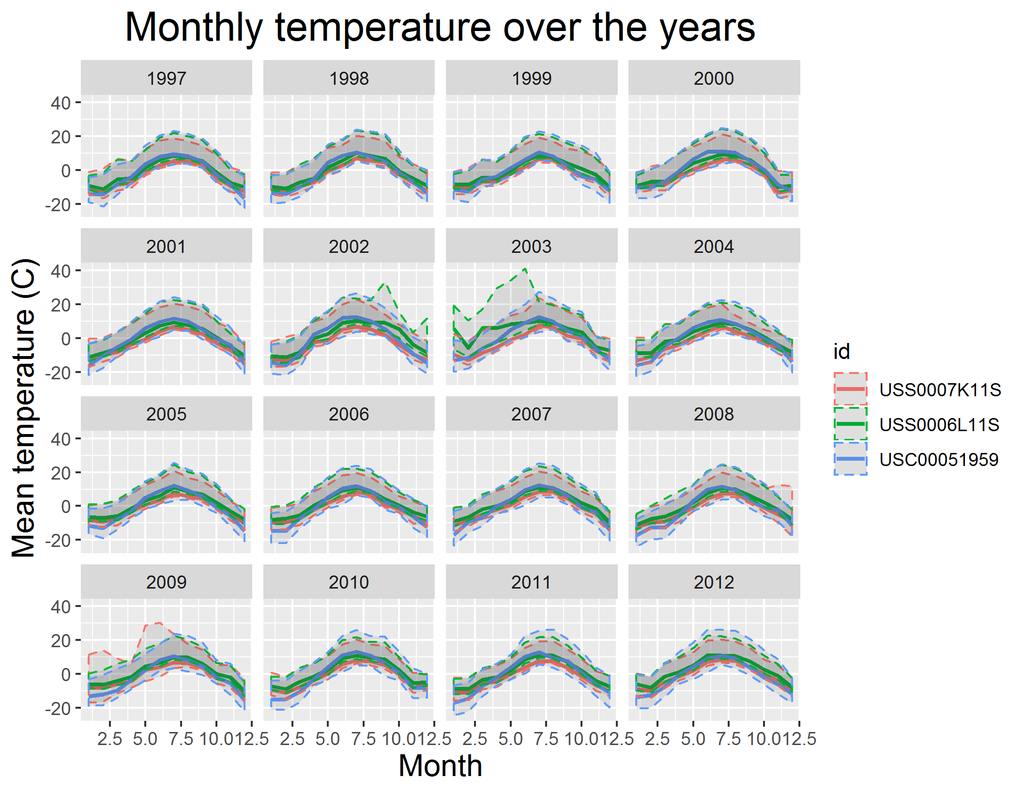

#### Precipitation

The solid lines are the total monthly precipitation in mm ([mean_prcp][Climwin Input Variables]).

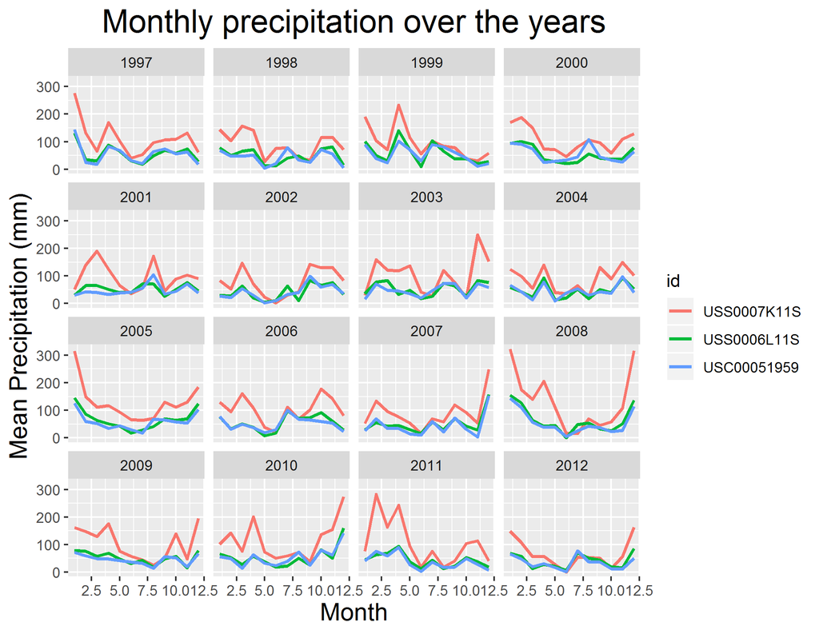

#References

Pol, Martijn van de, Liam D. Bailey, Nina McLean, Laurie Rijsdijk, Callum R. Lawson, and Lyanne Brouwer. 2016. “Identifying the best climatic predictors in ecology and evolution.” *Methods in Ecology and Evolution* 7 (10): 1246–57. doi:10.1111/2041-210X.12590.

[^1]: see the [NOAA website](https://www1.ncdc.noaa.gov/pub/data/ghcn/daily/readme.txt) for more detailed information